# Airline On-Time Performance Data Exploration

## Multivariate Exploration

first let's look a relation between the distance and reason of cancellation across the years

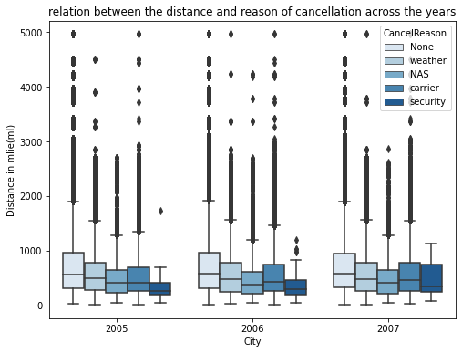

```python
plt.figure(figsize = [8, 6])
sb.boxplot(data = df, y = 'Distance', x = df['Date'].dt.year,hue='CancelReason' , palette = 'Blues')
plt.title('relation between the distance and reason of cancellation across the years')
plt.xlabel('City')
plt.ylabel('Distance in mlie(ml)')
plt.show()
```

it seems that in long distances the flights tend to be not cancelled

### now let's see the relation between the the Distance and the Actual Elapsed time and see the effect of both ArrDelay and DepDelay on the Elapsed time

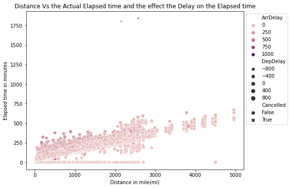

```python
plt.figure(figsize = (8,6))
sb.scatterplot(data = df.sample(100000), x = 'Distance', y = 'ActualElapsedTime',hue ='ArrDelay' ,size='DepDelay',style = 'Cancelled')
plt.legend(bbox_to_anchor=(1,1))
plt.title('Distance Vs the Actual Elapsed time and the effect the Delay on the Elapsed time')
plt.xlabel('Distance in mile(ml)')
plt.ylabel('Elapsed time in minutes')
plt.show()
```

we can see high correlation between the Distance and the actual elapsed time also we notice that most of delays have ouccured in the short distances also we can the the flights with high ariaval delay also tend to have high deprature dely. finally we can see the both the arrival delay and deprature delay barley affect the actual elapsed time

### let say the realation between the Distance and the cancelled flights for the top 5 cities

```python
top_dest_cities = df[df['DestCity'].isin(top_citites.head()['DestCity'])]
```

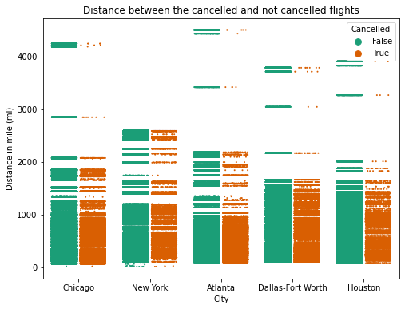

```python
fig = plt.figure(figsize = [8,6])
ax = sb.stripplot(data = top_dest_cities, x = 'DestCity',y = 'Distance', hue = 'Cancelled',
                 palette = 'Dark2',size = 2 ,jitter = 0.35, dodge = True)
plt.title('Distance between the cancelled and not cancelled flights')
plt.xlabel('City')
plt.ylabel('Distance in mile (ml)')
plt.show()
```

we can see that most of cancelled flights for all cities occured in the short distaces more thant the long distances

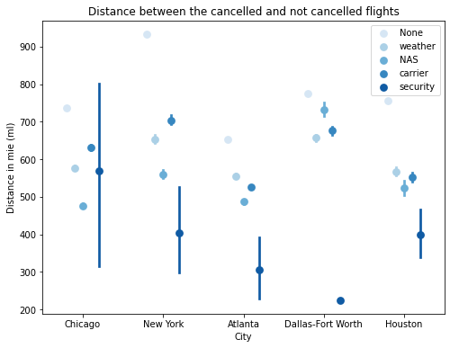

```python
fig = plt.figure(figsize = [8,6])
ax = sb.pointplot(data = top_dest_cities, x = 'DestCity', y = 'Distance', hue = 'CancelReason',
           palette = 'Blues', linestyles = '', dodge = 0.4)
plt.title('Distance between the cancelled and not cancelled flights')
plt.xlabel('City')
plt.ylabel('Distance in mie (ml)')
plt.legend(bbox_to_anchor=(1,1))
plt.show();
```

even for all reasons of cancellation for all ciites still most of number cancelled flights for all cities occured in the short distaces more thant the long distances and it's maybe because flights in long distances have to be more prepared

### also let's continue to do some analysis for the top visted cities

### let start to see the arriavl delaya and deprature delay for each flight between them

```python
most_flights = df[df['DestCity'].isin(top_cities)&df['OriginCity'].isin(top_cities)]
```

```python
def hist2dgrid(x, y, **kwargs):
    palette = kwargs.pop('color')
    plt.hist2d(x, y, cmap = palette, cmin = 0.5)
```

```python
most_flights
```

|  | Date | Cancelled | CancelReason | TotalDelay | ArrDelay | DepDelay | ActualElapsedTime | OriginCity | DestCity | Diverted | Distance |
| --- | --- | --- | --- | --- | --- | --- | --- | --- | --- | --- | --- |
| 107265 | 2005-01-01 | False | None | 0 | -13.0 | 21.0 | 197.0 | Los Angeles | Chicago | False | 1745 |
| 107266 | 2005-02-01 | False | None | 0 | -6.0 | 11.0 | 214.0 | Los Angeles | Chicago | False | 1745 |
| 107267 | 2005-03-01 | False | None | 20 | 20.0 | 38.0 | 213.0 | Los Angeles | Chicago | False | 1745 |
| 107268 | 2005-04-01 | False | None | 0 | -9.0 | 0.0 | 222.0 | Los Angeles | Chicago | False | 1745 |
| 107269 | 2005-05-01 | False | None | 0 | 4.0 | 7.0 | 228.0 | Los Angeles | Chicago | False | 1745 |
| ... | ... | ... | ... | ... | ... | ... | ... | ... | ... | ... | ... |
| 20795063 | 2007-02-12 | False | None | 0 | 8.0 | 20.0 | 153.0 | Chicago | Houston | False | 937 |
| 20795064 | 2007-02-12 | False | None | 0 | 3.0 | 0.0 | 168.0 | Chicago | Houston | False | 937 |
| 20795065 | 2007-02-12 | False | None | 100 | 100.0 | 100.0 | 165.0 | Chicago | Houston | False | 937 |
| 20795066 | 2007-02-12 | False | None | 34 | 34.0 | 3.0 | 196.0 | Chicago | Houston | False | 937 |
| 20795067 | 2007-02-12 | False | None | 0 | 5.0 | 1.0 | 169.0 | Chicago | Houston | False | 937 |

805526 rows × 11 columns

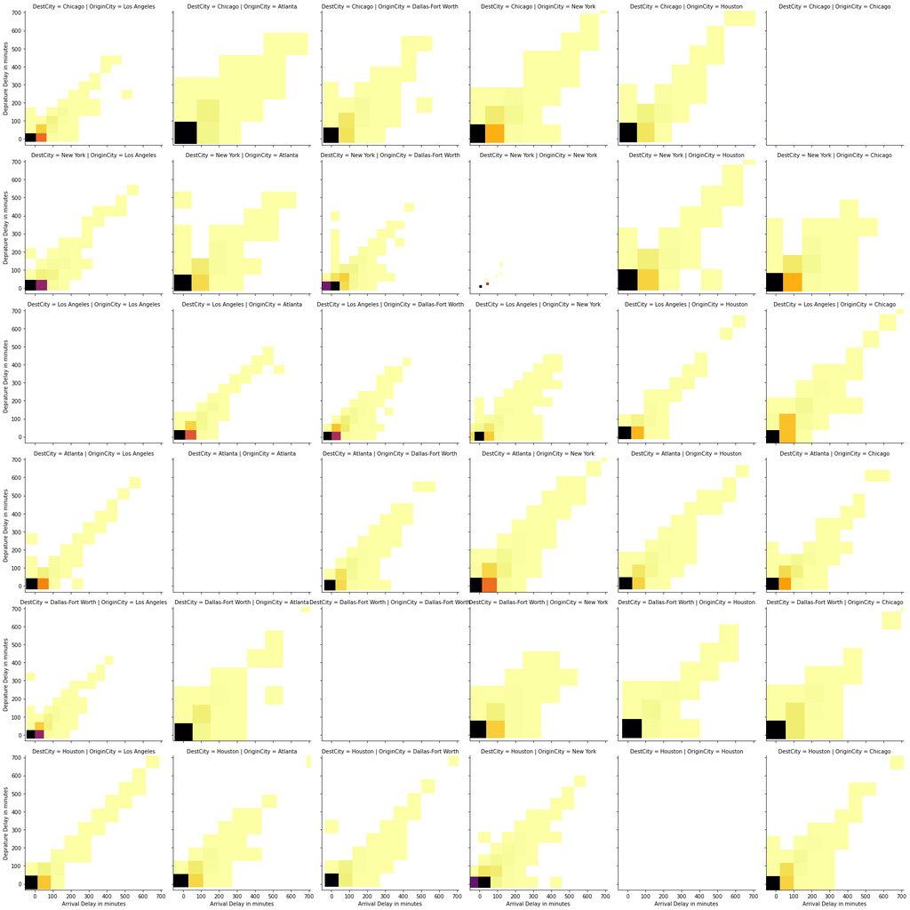

```python
g = sb.FacetGrid(data = most_flights,row = 'DestCity', col = 'OriginCity', size = 4,)
g.map(hist2dgrid, 'ArrDelay', 'DepDelay', color = 'inferno_r', margin_titles = True)
g.set_xlabels('Arrival Delay in minutes')
g.set_ylabels('Deprature Delay in minutes')

plt.show()
```

it seem that the there is nothing abnormal most of flights for all ciites were in their time aslo we can see that The flight between Chicago and New York has more delyed flights than the flights between the other cities and that maybe becuse the high number of flights between thesse two cities

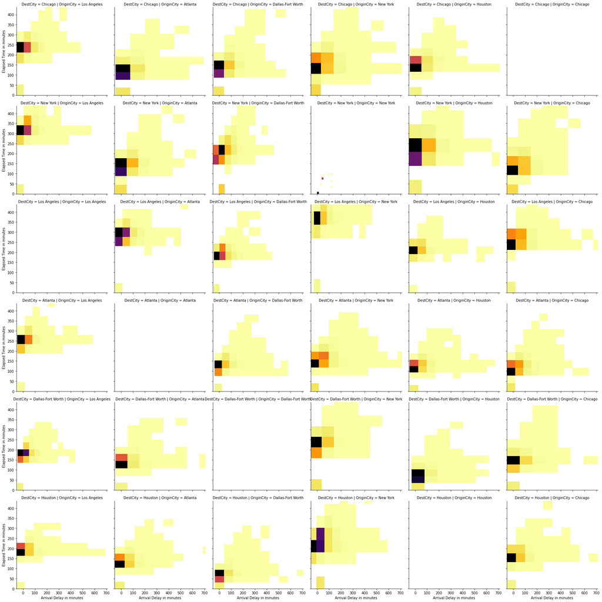

```python
g = sb.FacetGrid(data = most_flights,row = 'DestCity', col = 'OriginCity', size = 4,)
g.map(hist2dgrid, 'ArrDelay', 'ActualElapsedTime', color = 'inferno_r', margin_titles = True)
g.set_xlabels('Arrival Delay in minutes')
g.set_ylabels('Elapsed Time in minutes')

plt.show()
```

### Were there any interesting or surprising interactions between features?

it seems there is nothing is abnormal all relation can be are make sene and can be aceepted although surprizingly the arrival delay and deprature delay don't really effect the elaped time

## Conclusions

There are 21,706,733 flight report in the dataset with 11 features (cDate,Cancelled,CancelReason,TotalDelay,ArrDelay DepDelay,ActualElapsedTime,OriginCity,DestCity,Diverted,Distance). some variables are numeric in nature like TotalDely Distance,... , and the variables DestCity, OriginCity,CancelReason are categorical ,also the variables cancelled and Diverted is boolean variables and finally the Date is datetime variable

the DestCity variable shows that Chiago has the most number of delyed flights, cancelled flights and also have the most vistied during all the cities

the data is almost nature maybe there are some weird outliers in some variable but it's still acceptable values, but for the countruction of the dataframe we did some cleaning process in order to be able to reduce the number of columns and that will will save more memory in it's turn.

the weather played a big role in cancelled flights as we saw the month january ,December, and febraury have the highest number of cancelled flights due to the bad weather also we found that the largest number of flights between two cities was between Chicago and New York also we see that the number on-ward flights is almost equal to the number of return flights

Chicago is almost the highest of everything has the most number of flights to/from aslo have the highest number of cancelled and delayed flights also the long distances surprisingly tend to be less cancelled or delayed also although Chicago has the highest number of cancelled flights it doesn't have the hightest cancellation ratio